# Análisis Exploratorio de Variables que Impactan en los Costos Médicos de Asegurados en la Región Sureste de EE. UU.

Emilia Fernández

2026-07-01

```r
library(tidyverse)
library(ggplot2)
library(corrplot)
library(knitr)
library(kableExtra)
```

# 1 Introducción

## 1.1 Descripción del dataset

El dataset completo está compuesto por **1.338 registros** de asegurados en Estados Unidos, distribuidos en 4 regiones: northwest, northeast, southwest y southeast.

Para este análisis se filtró por la **región southeast**, con una muestra total de **364 individuos**.

Antes de comenzar el análisis se realizó una revisión de calidad de los datos. Se verificó que no existieran valores nulos, registros duplicados ni campos vacíos, por lo que no fue necesario realizar correcciones sobre la muestra.

```r
df <- read.csv("../data/insurance.csv")
se <- df %>% filter(region == "southeast")

cat("Registros totales:", nrow(df), "\n")
```

```
## Registros totales: 1338
```

```r
cat("Registros región southeast:", nrow(se), "\n")
```

```
## Registros región southeast: 364
```

```r
cat("Valores nulos:", sum(is.na(se)), "\n")
```

```
## Valores nulos: 0
```

```r
cat("Registros duplicados:", sum(duplicated(se)), "\n")
```

```
## Registros duplicados: 0
```

## 1.2 Variables analizadas

| Variable | Descripción |
| --- | --- |
| `age` | Edad del beneficiario principal |
| `sex` | Género (hombre, mujer) |
| `bmi` | Índice de Masa Corporal (IMC) |
| `children` | Número de hijos cubiertos por el seguro |
| `smoker` | Condición de fumador |
| `charges` | Costos médicos individuales anuales (USD) |
| `region` | Área de residencia en EE. UU. |

## 1.3 Objetivo

Identificar cuáles son las variables más asociadas a los costos médicos (`charges`) de los asegurados de la región southeast y comprender su comportamiento.

# 2 Análisis Univariado

## 2.1 Tabla descriptiva de variables numéricas

```r
tabla_desc <- se %>%
  select(age, bmi, children, charges) %>%
  summarise(across(everything(), list(
    Media   = ~round(mean(.),   2),
    Mediana = ~round(median(.), 2),
    DesvStd = ~round(sd(.),     2),
    CV      = ~round(sd(.) / mean(.) * 100, 2),
    Min     = ~round(min(.), 2),
    Q1      = ~round(quantile(., 0.25), 2),
    Q3      = ~round(quantile(., 0.75), 2),
    Max     = ~round(max(.), 2)
  ))) %>%
  pivot_longer(everything(),
               names_to  = c("Variable", ".value"),
               names_sep = "_") %>%
  rename_with(toupper)

kable(tabla_desc, caption = "Estadísticos descriptivos – Región Southeast") %>%
  kable_styling(bootstrap_options = c("striped", "hover", "condensed"),
                full_width = FALSE)
```

Estadísticos descriptivos – Región Southeast

| VARIABLE | MEDIA | MEDIANA | DESVSTD | CV | MIN | Q1 | Q3 | MAX |
| --- | --- | --- | --- | --- | --- | --- | --- | --- |
| age | 38.94 | 39.00 | 14.16 | 36.38 | 18.00 | 26.75 | 51.00 | 64.00 |
| bmi | 33.36 | 33.33 | 6.48 | 19.42 | 19.80 | 28.57 | 37.81 | 53.13 |
| children | 1.05 | 1.00 | 1.18 | 112.18 | 0.00 | 0.00 | 2.00 | 5.00 |
| charges | 14735.41 | 9294.13 | 13971.10 | 94.81 | 1121.87 | 4440.89 | 19526.29 | 63770.43 |

## 2.2 Costos médicos (charges)

La variable `charges` presenta una **mediana de $9.294,13** y una **media de $14.735,41**, lo que evidencia una **asimetría positiva**: algunos individuos con costos elevados desplazan el promedio por encima de la mediana.

La desviación estándar (13.971,10) y el coeficiente de variación (94.81%) reflejan un alto grado de dispersión.

```r
Q1  <- quantile(se$charges, 0.25)
Q3  <- quantile(se$charges, 0.75)
IQR_val <- Q3 - Q1
lim_sup <- Q3 + 1.5 * IQR_val
outliers <- se %>% filter(charges > lim_sup)

cat("Límite superior IQR:", round(lim_sup, 2), "\n")
```

```
## Límite superior IQR: 42154.39
```

```r
cat("Outliers identificados:", nrow(outliers), "\n")
```

```
## Outliers identificados: 26
```

```r
cat("Porcentaje sobre la muestra:", round(nrow(outliers)/nrow(se)*100, 2), "%\n")
```

```
## Porcentaje sobre la muestra: 7.14 %
```

```r
cat("Percentil 90:", round(quantile(se$charges, 0.90), 2), "\n")
```

```
## Percentil 90: 39827.02
```

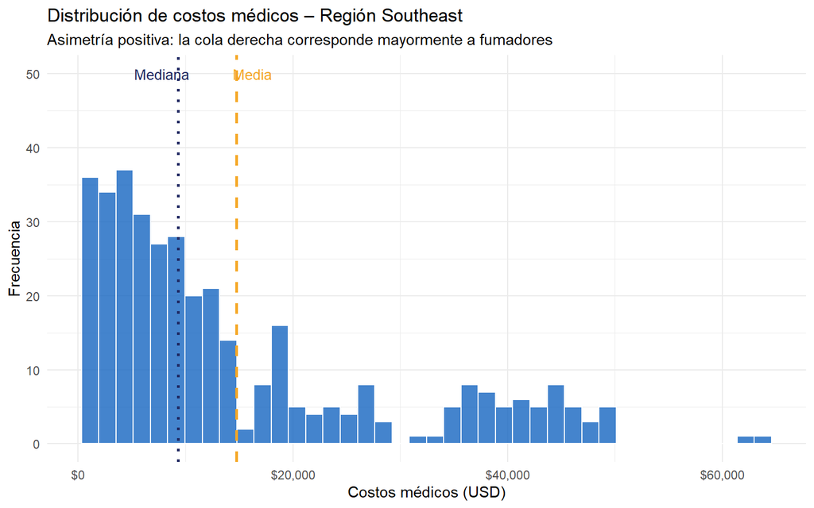

```r
ggplot(se, aes(x = charges)) +
  geom_histogram(bins = 40, fill = "#1565C0", alpha = 0.8, color = "white") +
  geom_vline(xintercept = mean(se$charges),   color = "#F5A623", linetype = "dashed", linewidth = 1) +
  geom_vline(xintercept = median(se$charges), color = "#1E2761", linetype = "dotted", linewidth = 1) +
  annotate("text", x = mean(se$charges)   + 1500, y = 50, label = "Media",   color = "#F5A623", size = 3.5) +
  annotate("text", x = median(se$charges) - 1500, y = 50, label = "Mediana", color = "#1E2761", size = 3.5) +
  scale_x_continuous(labels = scales::dollar_format()) +
  labs(title = "Distribución de costos médicos – Región Southeast",
       subtitle = "Asimetría positiva: la cola derecha corresponde mayormente a fumadores",
       x = "Costos médicos (USD)", y = "Frecuencia") +
  theme_minimal()
```

## 2.3 Índice de Masa Corporal (BMI)

El IMC se clasifica en las siguientes categorías:

| IMC | Categoría |
| --- | --- |
| < 18.5 | Por debajo del peso |
| 18.5 – 24.9 | Saludable |
| 25.0 – 29.9 | Sobrepeso |
| 30.0 – 39.9 | Obesidad |
| > 40 | Obesidad grave |

```r
se <- se %>%
  mutate(bmi_cat = case_when(
    bmi < 18.5             ~ "Bajo peso",
    bmi >= 18.5 & bmi < 25 ~ "Saludable",
    bmi >= 25   & bmi < 30 ~ "Sobrepeso",
    bmi >= 30   & bmi < 40 ~ "Obesidad",
    bmi >= 40              ~ "Obesidad grave"
  ))

se %>%
  count(bmi_cat) %>%
  mutate(porcentaje = round(n / sum(n) * 100, 2)) %>%
  arrange(desc(porcentaje)) %>%
  kable(col.names = c("Categoría IMC", "N", "%"),
        caption = "Distribución por categoría de IMC") %>%
  kable_styling(bootstrap_options = c("striped", "hover"), full_width = FALSE)
```

Distribución por categoría de IMC

| Categoría IMC | N | % |
| --- | --- | --- |
| Obesidad | 188 | 51.65 |
| Sobrepeso | 80 | 21.98 |
| Obesidad grave | 55 | 15.11 |
| Saludable | 41 | 11.26 |

El promedio de IMC en la región southeast es **33.36**, ubicándose en la categoría de **obesidad**. El **66.76%** de la población presenta un IMC superior a 30.

## 2.4 Sexo (sex)

```r
se %>%
  count(sex) %>%
  mutate(
    porcentaje = round(n / sum(n) * 100, 2),
    sex = ifelse(sex == "male", "Hombre", "Mujer")
  ) %>%
  kable(col.names = c("Sexo", "N", "%")) %>%
  kable_styling(full_width = FALSE)
```

| Sexo | N | % |
| --- | --- | --- |
| Mujer | 175 | 48.08 |
| Hombre | 189 | 51.92 |

La muestra está distribuida de forma equilibrada: **51.92% hombres** y **48.08% mujeres**.

## 2.5 Cantidad de hijos (children)

```r
se %>%
  mutate(hijos_grupo = ifelse(children >= 3, "3+", as.character(children))) %>%
  count(hijos_grupo) %>%
  arrange(hijos_grupo) %>%
  kable(col.names = c("Hijos", "N")) %>%
  kable_styling(full_width = FALSE)
```

| Hijos | N |
| --- | --- |
| 0 | 157 |
| 1 | 95 |
| 2 | 66 |
| 3+ | 46 |

# 3 Análisis Bivariado

## 3.1 Matriz de correlación

Las variables `sex` y `smoker` son categóricas y se codificaron como binarias (`sex_num`, `smoker_num`) antes de calcular las correlaciones.

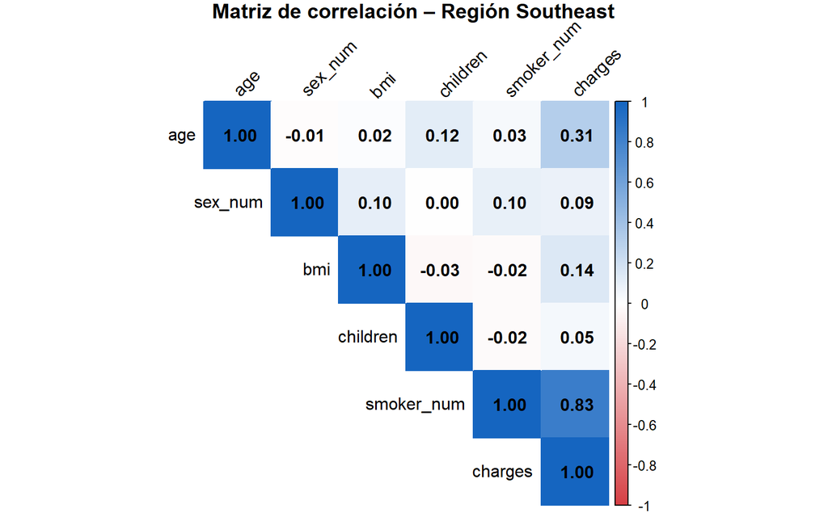

```r
se_num <- se %>%
  mutate(
    smoker_num = as.numeric(smoker == "yes"),
    sex_num    = as.numeric(sex == "male")
  ) %>%
  select(age, sex_num, bmi, children, smoker_num, charges)

cor_matrix <- cor(se_num)

corrplot(cor_matrix,
         method  = "color",
         type    = "upper",
         addCoef.col = "black",
         tl.col  = "black",
         tl.srt  = 45,
         col     = colorRampPalette(c("#D64045", "white", "#1565C0"))(200),
         title   = "Matriz de correlación – Región Southeast",
         mar     = c(0, 0, 1, 0))
```

Se observa una **correlación positiva fuerte entre `smoker_num` y `charges` (r = 0.83)**. El resto de las variables muestran correlaciones débiles.

## 3.2 Costos médicos según tabaquismo

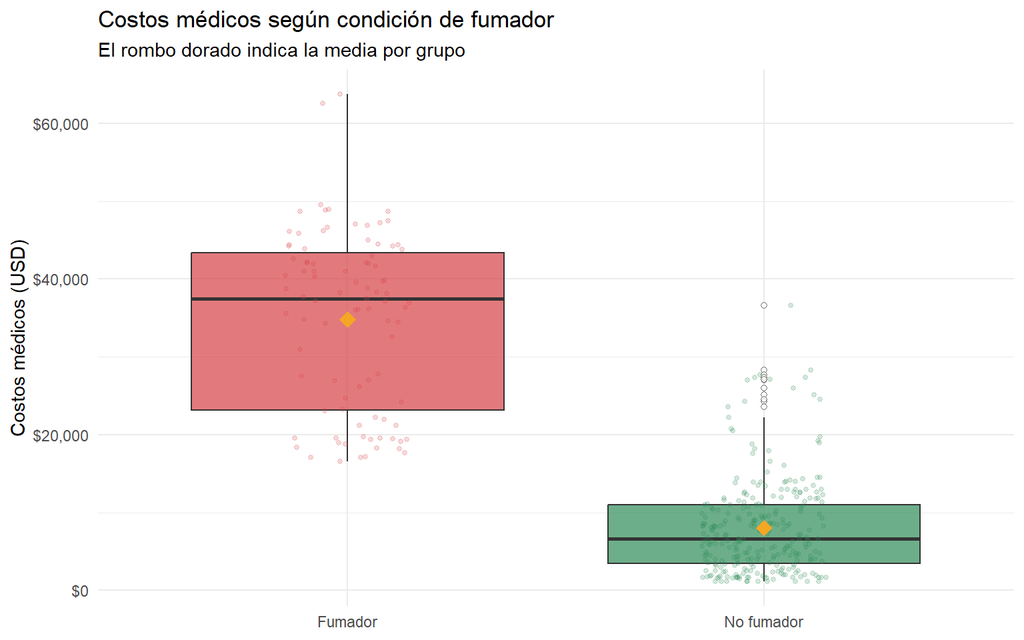

```r
se %>%
  mutate(smoker_label = ifelse(smoker == "yes", "Fumador", "No fumador")) %>%
  ggplot(aes(x = smoker_label, y = charges, fill = smoker_label)) +
  geom_boxplot(alpha = 0.7, outlier.shape = 21, outlier.fill = "white") +
  geom_jitter(aes(color = smoker_label), width = 0.15, alpha = 0.2, size = 1) +
  stat_summary(fun = mean, geom = "point", shape = 18, size = 4, color = "#F5A623") +
  scale_fill_manual(values  = c("Fumador" = "#D64045", "No fumador" = "#2E8B57")) +
  scale_color_manual(values = c("Fumador" = "#D64045", "No fumador" = "#2E8B57")) +
  scale_y_continuous(labels = scales::dollar_format()) +
  labs(title    = "Costos médicos según condición de fumador",
       subtitle = "El rombo dorado indica la media por grupo",
       x = NULL, y = "Costos médicos (USD)") +
  theme_minimal() +
  theme(legend.position = "none")
```

```r
se %>%
  group_by(smoker) %>%
  summarise(
    N       = n(),
    Media   = round(mean(charges), 2),
    Mediana = round(median(charges), 2)
  ) %>%
  mutate(smoker = ifelse(smoker == "yes", "Fumador", "No fumador")) %>%
  kable(
    col.names = c("Grupo", "N", "Costo promedio (USD)", "Costo mediano (USD)"),
    caption = "Costos médicos por condición de fumador"
  ) %>%
  kable_styling(full_width = FALSE)
```

Costos médicos por condición de fumador

| Grupo | N | Costo promedio (USD) | Costo mediano (USD) |
| --- | --- | --- | --- |
| No fumador | 273 | 8032.22 | 6652.53 |
| Fumador | 91 | 34845.00 | 37484.45 |

El **25% de la muestra son fumadores**. Los fumadores presentan costos **4.3 veces mayores** que los no fumadores.

## 3.3 Costos médicos según IMC

```r
modelo_bmi <- lm(charges ~ bmi, data = se)
cat("R² solo IMC:", round(summary(modelo_bmi)$r.squared, 4))
```

```
## R² solo IMC: 0.0204
```

Con R² = 0.0204, el IMC por sí solo explica una **proporción muy pequeña** de la variabilidad en costos médicos.

## 3.4 Costos médicos según sexo

```r
se %>%
  group_by(sex) %>%
  summarise(Media = round(mean(charges), 2)) %>%
  mutate(sex = ifelse(sex == "male", "Hombre", "Mujer")) %>%
  kable(col.names = c("Sexo", "Costo promedio (USD)")) %>%
  kable_styling(full_width = FALSE)
```

| Sexo | Costo promedio (USD) |
| --- | --- |
| Mujer | 13499.67 |
| Hombre | 15879.62 |

La correlación entre sexo y costos es débil (r = 0.09), por lo que no resulta un factor relevante de forma independiente.

## 3.5 Costos médicos según cantidad de hijos

```r
se %>%
  mutate(hijos_grupo = ifelse(children >= 3, "3+", as.character(children))) %>%
  group_by(hijos_grupo) %>%
  summarise(Media = round(mean(charges), 2)) %>%
  arrange(hijos_grupo) %>%
  kable(col.names = c("Hijos", "Costo promedio (USD)")) %>%
  kable_styling(full_width = FALSE)
```

| Hijos | Costo promedio (USD) |
| --- | --- |
| 0 | 14309.87 |
| 1 | 13687.04 |
| 2 | 15728.47 |
| 3+ | 16928.10 |

La correlación entre hijos y costos es débil — no explica los costos elevados.

# 4 Perfil de Riesgo

```r
outliers_detalle <- se %>%
  filter(charges > lim_sup) %>%
  summarise(
    Total         = n(),
    Pct_fumadores = round(mean(smoker == "yes") * 100, 1),
    Pct_obesos    = round(mean(bmi > 30) * 100, 1),
    Edad_promedio = round(mean(age), 1)
  )

kable(outliers_detalle,
      col.names = c("Total outliers", "% Fumadores", "% IMC > 30", "Edad promedio"),
      caption   = "Características de los 26 outliers de costos médicos") %>%
  kable_styling(full_width = FALSE)
```

Características de los 26 outliers de costos médicos

| Total outliers | % Fumadores | % IMC > 30 | Edad promedio |
| --- | --- | --- | --- |
| 26 | 100 | 100 | 51.2 |

El **100% de los outliers son fumadores** con IMC mayor a 30, y su edad promedio es de **51 años** — considerablemente mayor al promedio general de la muestra (39 años).

> **Perfil de riesgo identificado:** persona fumadora, con obesidad (IMC > 30) y de mayor edad.

# 5 Modelos de Regresión

## 5.1 Modelo 1: Solo IMC

```r
m1 <- lm(charges ~ bmi, data = se)
cat("R²:", round(summary(m1)$r.squared, 4))
```

```
## R²: 0.0204
```

## 5.2 Modelo 2: Solo fumador

```r
m2 <- lm(charges ~ smoker, data = se)
cat("R²:", round(summary(m2)$r.squared, 4))
```

```
## R²: 0.6925
```

## 5.3 Modelo 3: Interacción fumador × IMC

```r
m3 <- lm(charges ~ smoker * bmi, data = se)
summary(m3)
```

```
##
## Call:
## lm(formula = charges ~ smoker * bmi, data = se)
##
## Residuals:
##      Min       1Q   Median       3Q      Max
## -15354.9  -4511.1   -735.5   3191.1  31261.1
##
## Coefficients:
##                Estimate Std. Error t value Pr(>|t|)
## (Intercept)     9147.59    2076.90   4.404 1.40e-05 ***
## smokeryes     -16789.77    3832.67  -4.381 1.55e-05 ***
## bmi              -33.35      61.03  -0.546    0.585
## smokeryes:bmi   1317.08     113.11  11.644  < 2e-16 ***
## ---
## Signif. codes:  0 '***' 0.001 '**' 0.01 '*' 0.05 '.' 0.1 ' ' 1
##
## Residual standard error: 6340 on 360 degrees of freedom
## Multiple R-squared:  0.7958, Adjusted R-squared:  0.7941
## F-statistic: 467.5 on 3 and 360 DF,  p-value: < 2.2e-16
```

[figure not shown]

```r
se %>%
  mutate(smoker_label = ifelse(smoker == "yes", "Fumador", "No fumador")) %>%
  ggplot(aes(x = bmi, y = charges, color = smoker_label)) +
  geom_point(alpha = 0.4, size = 1.8) +
  geom_smooth(method = "lm", se = TRUE, linewidth = 1.5) +
  geom_vline(xintercept = 30, linetype = "dashed", color = "#1E2761", alpha = 0.5) +
  annotate("text", x = 30.5, y = 55000,
           label = "IMC = 30\n(obesidad)", color = "#1E2761", size = 3.2, hjust = 0) +
  scale_color_manual(values = c("Fumador" = "#D64045", "No fumador" = "#2E8B57")) +
  scale_y_continuous(labels = scales::dollar_format()) +
  labs(title    = "IMC vs. costos médicos según condición de fumador",
       subtitle = "En fumadores, cada punto de IMC suma ~$1.284 en costos",
       x = "IMC", y = "Costos médicos (USD)", color = NULL) +
  theme_minimal()
```